# Семинар 2. Таблицы сопряжённости, корреляции и манипуляции с данными

May 22, 2018

# 1 Гремучая смесь R и маркдаун

В нашем документе смешан код R внутри сереньких блоков и текст с разметкой маркдаун. Эту смесь можно превратить в готовый документ, нажав на клубок ниток со словом `Knit` прямо над документом.

Попробуйте кликнуть `Knit`:)

Будьте осторожны при редактировании R-маркдаун! Например, если Вовочка удалит один закрывающий разделитель, то компьютер будет воспринимать человеческий текст как команды R и выдаст ошибку.

Основные опции блоков кода: - message=TRUE/FALSE - выводить ли в отчёт *сообщения* - warning=TRUE/FALSE - выводить ли в отчёт *предупреждения* - echo=TRUE/FALSE - копировать ли в отчёт сами команды R - eval=TRUE/FALSE - выполнять ли команды внутри блока кода - “Самый важный шмат кода” - название блока кода :)

Подробнее про фантастические возможности R+маркдаун: `Help` - `Cheatsheets` - `R markdown`.

Сделайте свой Rstudio уютненьким: `Tools` - `Global Options` - `Appearance` :)

# 2 Работа с очень качественными переменными.

В R есть много типов переменных, например: - количественные (double, dbl) - целочисленные (integer, int) - дата и время (datetime, dttm) - логические (logical, lgl) - качественные/категориальные/факторные (factor, fctr) - текстовые (character, chr)

Существенной разницы между текстовыми и качественными нет. Отличия качественных от текстовых: - ограничено количество значений, скажем только “зима”, “весна”, “лето”, “осень” - можно задать порядок “магистр” > “бакалавр” > “школьник” - занимают меньше места в памяти

Подключаем нужные пакеты и вперёд!

```r
library(tidyverse) # обработка данных, графики...
library(vcd) # мозаичные графики для качественных переменных
```

```r
library(skimr) # описательные статистики
library(rio) # импорт фантастического количества форматов данных
library(ggalluvial) # потоковые ???? графики для качественных переменных
library(nycflights13) # набор данных о вылетах из Нью-Йорка
library(corrplot) # визуализация корреляций
library(reshape2) # длинные и широкие таблицы
```

Узнаём частотность каждой категории переменной `color`:

```r
table(diamonds$color)
```

```
##
##     D     E     F     G     H     I     J
##  6775  9797  9542 11292  8304  5422  2808
```

```r
skim(diamonds)
```

```
## Skim summary statistics
##  n obs: 53940
##  n variables: 10
##
## Variable type: factor
##  variable missing complete     n n_unique
##   clarity       0    53940 53940        8
##     color       0    53940 53940        7
##       cut       0    53940 53940        5
##                                     top_counts ordered
##   SI1: 13065, VS2: 12258, SI2: 9194, VS1: 8171    TRUE
##            G: 11292, E: 9797, F: 9542, H: 8304    TRUE
##  Ide: 21551, Pre: 13791, Ver: 12082, Goo: 4906    TRUE
##
## Variable type: integer
##  variable missing complete     n   mean      sd  p0 p25  p50     p75  p100
##     price       0    53940 53940 3932.8 3989.44 326 950 2401 5324.25 18823
##      hist
##  ▇▃▂▁▁▁▁▁
##
## Variable type: numeric
##  variable missing complete     n  mean   sd   p0   p25   p50   p75  p100
##     carat       0    53940 53940  0.8  0.47  0.2  0.4   0.7   1.04  5.01
##     depth       0    53940 53940 61.75 1.43 43   61    61.8  62.5  79
##     table       0    53940 53940 57.46 2.23 43   56    57    59    95
##         x       0    53940 53940  5.73 1.12  0    4.71  5.7   6.54 10.74
##         y       0    53940 53940  5.73 1.14  0    4.72  5.71  6.54 58.9
##         z       0    53940 53940  3.54 0.71  0    2.91  3.53  4.04 31.8
##      hist
##  ▇▅▁▁▁▁▁▁
##  ▁▁▁▃▇▁▁▁
##  ▁▅▇▁▁▁▁▁
##  ▁▁▁▇▇▃▁▁
##  ▇▁▁▁▁▁▁▁
##  ▇▃▁▁▁▁▁▁
```

Или получаем список категорий без количеств:

```r
levels(diamonds$color)
```

```
## [1] "D" "E" "F" "G" "H" "I" "J"
```

Попробуем объединить три категории в одну: “D”, “E”, “F” в “United”:

```r
diamonds2 <- mutate(diamonds, color = fct_collapse(color, United = c('D', 'E', 'F')))
table(diamonds2$color)
```

```
##
## United      G      H      I      J
##  26114  11292   8304   5422   2808
```

- Упражнение 1.

Объедините категории “Premium” и “Ideal” огранки `cut` в категорию ‘Best’. Обратите внимание на то, какие названия пишутся в кавычках.

```r
diamonds3 <- mutate(diamonds,
                    cut = fct_collapse(cut, Best = c('Premium', "Ideal")))
table(diamonds3$cut)
```

```
##
##      Fair      Good Very Good      Best
##      1610      4906     12082     35342
```

# 3 Таблицы сопряжённости

Рассмотрим данные по зарплатам со страницы [UCI](http://archive.ics.uci.edu/ml/machine-learning-databases/adult/). Загружаем и смотрим на них:

```r
adult <- import('adult.rds') # загружаем данные
glimpse(adult)
```

```
## Observations: 32,561
## Variables: 15
## $ V1  <int> 39, 50, 38, 53, 28, 37, 49, 52, 31, 42, 37, 30, 23, 32, 40...
## $ V2  <fct> State-gov, Self-emp-not-inc, Private, Private, Private, Pr...
## $ V3  <int> 77516, 83311, 215646, 234721, 338409, 284582, 160187, 2096...
## $ V4  <fct> Bachelors, Bachelors, HS-grad, 11th, Bachelors, Masters, 9...
## $ V5  <int> 13, 13, 9, 7, 13, 14, 5, 9, 14, 13, 10, 13, 13, 12, 11, 4,...
## $ V6  <fct> Never-married, Married-civ-spouse, Divorced, Married-civ-s...
## $ V7  <fct> Adm-clerical, Exec-managerial, Handlers-cleaners, Handlers...
## $ V8  <fct> Not-in-family, Husband, Not-in-family, Husband, Wife, Wife...
## $ V9  <fct> White, White, White, Black, Black, White, Black, White, Wh...
## $ V10 <fct> Male, Male, Male, Male, Female, Female, Female, Male, Fema...
## $ V11 <int> 2174, 0, 0, 0, 0, 0, 0, 0, 14084, 5178, 0, 0, 0, 0, 0, 0, ...
## $ V12 <int> 0, 0, 0, 0, 0, 0, 0, 0, 0, 0, 0, 0, 0, 0, 0, 0, 0, 0, 0, 0...
## $ V13 <int> 40, 13, 40, 40, 40, 40, 16, 45, 50, 40, 80, 40, 30, 50, 40...
## $ V14 <fct> United-States, United-States, United-States, United-States...
## $ V15 <fct> <=50K, <=50K, <=50K, <=50K, <=50K, <=50K, <=50K, >50K, >50...
```

Переменные в файле были без названий и потому R их сиротливо назвал `V1`, `V2` :) Полное [описание переменных UCI](http://archive.ics.uci.edu/ml/machine-learning-databases/adult/adult.names).

```r
adult2 <- select(adult, sector = V2, race = V10, wage = V15)
glimpse(adult2)
```

```
## Observations: 32,561
## Variables: 3
## $ sector <fct> State-gov, Self-emp-not-inc, Private, Private, Private,...
## $ race   <fct> Male, Male, Male, Male, Female, Female, Female, Male, F...
## $ wage   <fct> <=50K, <=50K, <=50K, <=50K, <=50K, <=50K, <=50K, >50K, ...
```

```r
skim(adult2)
```

```
## Skim summary statistics
##  n obs: 32561
##  n variables: 3
##
## Variable type: factor
##  variable missing complete     n n_unique
##      race       0    32561 32561        2
##    sector       0    32561 32561        9
##      wage       0    32561 32561        2
##                                 top_counts ordered
##              Mal: 21790, Fem: 10771, NA: 0   FALSE
##  Pri: 22696, Sel: 2541, Loc: 2093, ?: 1836   FALSE
##               <=5: 24720, >50: 7841, NA: 0   FALSE
```

- Упражнение 2:
- Сколько уникальных значений у переменных `wage` и `sector`?

Для качественных переменных можно создавать таблицы сопряжённости. По строкам указываются значения одной переменной, по столбцам — другой, а на пересечении стоит количество наблюдений.

Таблицу сопряжённости можно создать командой `table()`:

```r
table(adult2$sector, adult2$wage)
```

```
##
##                    <=50K  >50K
##   ?                 1645   191
##   Federal-gov        589   371
##   Local-gov         1476   617
##   Never-worked         7     0
##   Private          17733  4963
##   Self-emp-inc       494   622
##   Self-emp-not-inc  1817   724
##   State-gov          945   353
##   Without-pay         14     0
```

Девять значений переменной `sector`- довольно много для ясной визуализации!

Но мы уже знаем, как объединять переменные, поэтому всех трудящихся на государство различать не будем. Также объединим в одну категорию предпринимателей, значения `Self-emp-not-inc`, `Self-emp-inc`.

```r
adult3 <- mutate(adult2, sector = fct_collapse(sector, Gov = c('State-gov', 'Federal-gov', 'Local-gov')))
adult4 <- mutate(adult3, sector = fct_collapse(sector, Self_emp = c('Self-emp-not-inc', 'Self-emp-inc')))
skim(adult4)
```

```
## Skim summary statistics
##  n obs: 32561
##  n variables: 3
##
## Variable type: factor
##  variable missing complete     n n_unique
##      race       0    32561 32561        2
##    sector       0    32561 32561        6
##      wage       0    32561 32561        2
##                                 top_counts ordered
##              Mal: 21790, Fem: 10771, NA: 0   FALSE
##  Pri: 22696, Gov: 4351, Sel: 3657, ?: 1836   FALSE
##               <=5: 24720, >50: 7841, NA: 0   FALSE
```

Строим более компактную таблицу сопряжённости:

```r
ctable <- table(adult4$sector, adult4$wage, dnn = c('Сектор', 'Зарплата'))
ctable
```

```
##               Зарплата
## Сектор         <=50K  >50K
##   ?             1645   191
##   Gov           3010  1341
##   Never-worked     7     0
##   Private      17733  4963
##   Self_emp      2311  1346
##   Without-pay     14     0
```

Визуализировать таблицу сопряжённости можно командой `mosaic()` из пакета `vcd`.

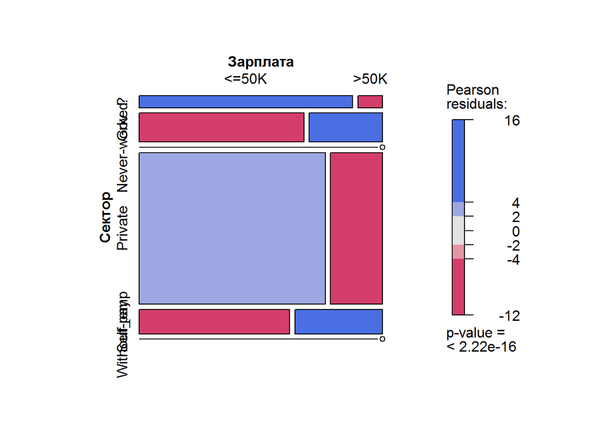

```r
mosaic(ctable, shade = TRUE, legend = TRUE)
```

Внутри функции сидит сама таблицу сопряжённости и опции: - `shade = TRUE`, чтобы график был цветным; - `legend = TRUE`, чтобы появилась легенда.

Можно ли считать зарплату и сектор независимыми признаками? Ответ даёт хи-квадрат тест Пирсона на независимость, `chisq.test()`.

```r
chisq.test(ctable)
```

```
##
##  Pearson's Chi-squared test
##
## data:  ctable
## X-squared = 687.39, df = 5, p-value < 2.2e-16
```

- Какой вывод можно сделать? Зависимы ли признаки?
- Упражнение 3.

Возьмём встроенный набор данных `Arthritis` о лечения артрита. - Посмотрите на описательные статистики. Сколько наблюдений в данных? - Сколько уникальных значений принимают факторные переменные? - Составьте таблицу сопряжённости для переменных `Treatment` и `Improved`. Укажите названия переменных. - Постройте мозаичный график `mosaic()` для таблицы сопряжённости. - Протестируйте независимость признаков `Treatment` и `Improved` используя оператор “затем”

```r
dta <- Arthritis
glimpse(Arthritis)
```

```
## Observations: 84
## Variables: 5
## $ ID        <int> 57, 46, 77, 17, 36, 23, 75, 39, 33, 55, 30, 5, 63, 8...
## $ Treatment <fct> Treated, Treated, Treated, Treated, Treated, Treated...
## $ Sex       <fct> Male, Male, Male, Male, Male, Male, Male, Male, Male...
## $ Age       <int> 27, 29, 30, 32, 46, 58, 59, 59, 63, 63, 64, 64, 69, ...
## $ Improved  <ord> Some, None, None, Marked, Marked, Marked, None, Mark...
```

```r
skim(Arthritis)
```

```
## Skim summary statistics
##  n obs: 84
##  n variables: 5
##
## Variable type: factor
##   variable missing complete  n n_unique                       top_counts
##   Improved       0       84 84        3 Non: 42, Mar: 28, Som: 14, NA: 0
##        Sex       0       84 84        2          Fem: 59, Mal: 25, NA: 0
##  Treatment       0       84 84        2          Pla: 43, Tre: 41, NA: 0
##  ordered
##     TRUE
##    FALSE
##    FALSE
##
## Variable type: integer
##  variable missing complete  n  mean    sd p0   p25  p50   p75 p100
##       Age       0       84 84 53.36 12.77 23 46    57   63      74
##        ID       0       84 84 42.5  24.39  1 21.75 42.5 63.25   84
##      hist
##  ▂▃▂▃▃▇▆▃
##  ▇▇▇▇▇▇▇▇
```

```r
new_ctable <- table(dta$Treatment, dta$Improved, dnn = c('Лечение', 'Улучшение'))
new_ctable
```

```
##          Улучшение
## Лечение   None Some Marked
##   Placebo   29    7      7
##   Treated   13    7     21
```

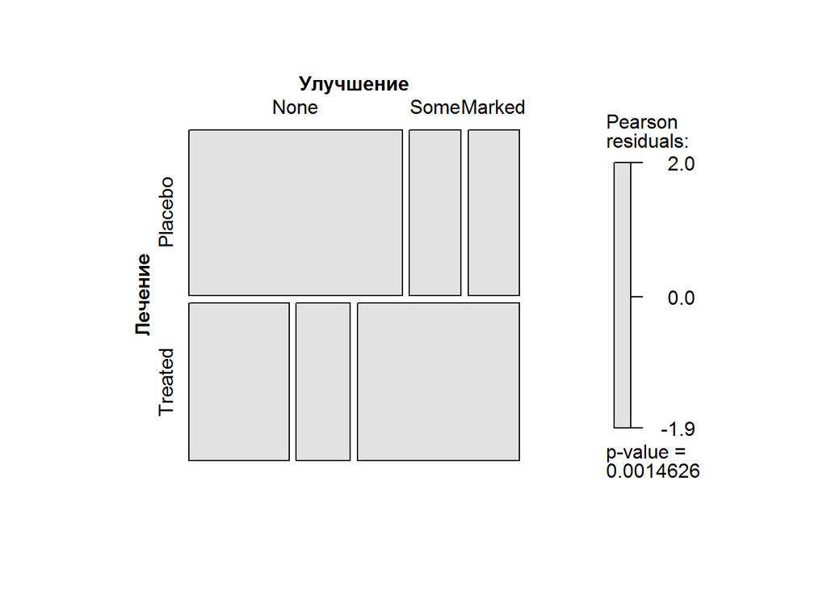

```r
mosaic(new_ctable, shade = TRUE, legend = TRUE)
```

```r
new_ctable %>% chisq.test(new_ctable) # применяем к таблице тест на независимость
```

```
##
##  Pearson's Chi-squared test
##
## data:  .
## X-squared = 13.055, df = 2, p-value = 0.001463
```

## 3.1 Очень много качественных переменных

Если качественных переменных больше двух, то разумнее посчитать таблицу частот. Мы группируем наблюдения по трём переменным и для каждой группы считаем количество наблюдений `n()`.

```r
freq_table <- group_by(adult4, wage, race, sector) %>% summarise(freq = n())
freq_table
```

```
## # A tibble: 20 x 4
## # Groups:   wage, race [?]
##    wage  race   sector        freq
##    <fct> <fct>  <fct>        <int>
##  1 <=50K Female ?              787
##  2 <=50K Female Gov           1361
##  3 <=50K Female Never-worked     2
##  4 <=50K Female Private       7026
##  5 <=50K Female Self_emp       411
##  6 <=50K Female Without-pay      5
##  7 <=50K Male   ?              858
##  8 <=50K Male   Gov           1649
##  9 <=50K Male   Never-worked     5
## 10 <=50K Male   Private      10707
## 11 <=50K Male   Self_emp      1900
## 12 <=50K Male   Without-pay      9
## 13 >50K  Female ?               52
## 14 >50K  Female Gov            278
## 15 >50K  Female Private        726
## 16 >50K  Female Self_emp       123
## 17 >50K  Male   ?              139
## 18 >50K  Male   Gov           1063
## 19 >50K  Male   Private       4237
## 20 >50K  Male   Self_emp      1223
```

- Упражнение 4.

Опишите словами, что изображено на графике:

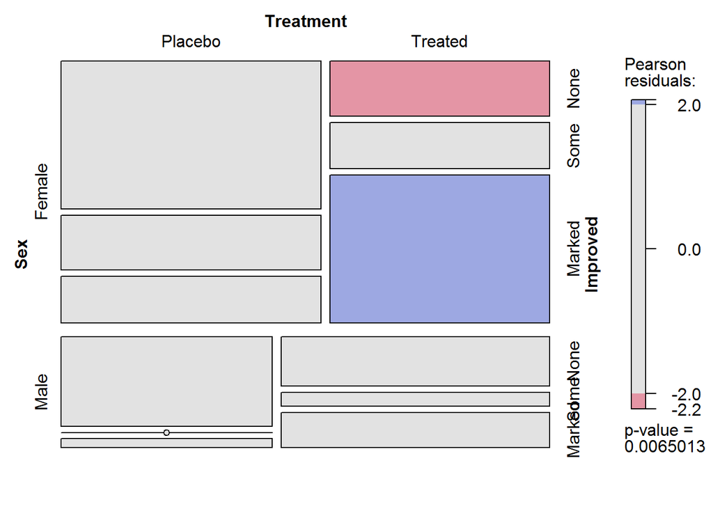

```r
mosaic(data = Arthritis, ~ Sex + Treatment + Improved, shade = TRUE, legend = TRUE)
```

# 4 Корреляционная матрица

Возьмём встроенный набор данных про автомобили `mtcars`. Напоминалка: посмотреть описание данных можно, набрав в консоли `?mtcars`.

- Упражнение 5.
- С помощью консоли вызовите справку и прочтите смысл переменных `cyl`, `mpg` и `am`.

Команда `cor()` поможет нам легко посчитать корреляции!

```r
glimpse(mtcars)
```

```
## Observations: 32
## Variables: 11
## $ mpg  <dbl> 21.0, 21.0, 22.8, 21.4, 18.7, 18.1, 14.3, 24.4, 22.8, 19....
## $ cyl  <dbl> 6, 6, 4, 6, 8, 6, 8, 4, 4, 6, 6, 8, 8, 8, 8, 8, 8, 4, 4, ...
## $ disp <dbl> 160.0, 160.0, 108.0, 258.0, 360.0, 225.0, 360.0, 146.7, 1...
## $ hp   <dbl> 110, 110, 93, 110, 175, 105, 245, 62, 95, 123, 123, 180, ...
## $ drat <dbl> 3.90, 3.90, 3.85, 3.08, 3.15, 2.76, 3.21, 3.69, 3.92, 3.9...
## $ wt   <dbl> 2.620, 2.875, 2.320, 3.215, 3.440, 3.460, 3.570, 3.190, 3...
## $ qsec <dbl> 16.46, 17.02, 18.61, 19.44, 17.02, 20.22, 15.84, 20.00, 2...
## $ vs   <dbl> 0, 0, 1, 1, 0, 1, 0, 1, 1, 1, 1, 0, 0, 0, 0, 0, 0, 1, 1, ...
## $ am   <dbl> 1, 1, 1, 0, 0, 0, 0, 0, 0, 0, 0, 0, 0, 0, 0, 0, 0, 1, 1, ...
## $ gear <dbl> 4, 4, 4, 3, 3, 3, 3, 4, 4, 4, 4, 3, 3, 3, 3, 3, 3, 4, 4, ...
## $ carb <dbl> 4, 4, 1, 1, 2, 1, 4, 2, 2, 4, 4, 3, 3, 3, 4, 4, 4, 1, 2, ...
```

```r
cars_cor <- cor(mtcars)
cars_cor
```

```
##             mpg        cyl       disp         hp        drat         wt
## mpg   1.0000000 -0.8521620 -0.8475514 -0.7761684  0.68117191 -0.8676594
## cyl  -0.8521620  1.0000000  0.9020329  0.8324475 -0.69993811  0.7824958
## disp -0.8475514  0.9020329  1.0000000  0.7909486 -0.71021393  0.8879799
## hp   -0.7761684  0.8324475  0.7909486  1.0000000 -0.44875912  0.6587479
## drat  0.6811719 -0.6999381 -0.7102139 -0.4487591  1.00000000 -0.7124406
## wt   -0.8676594  0.7824958  0.8879799  0.6587479 -0.71244065  1.0000000
## qsec  0.4186840 -0.5912421 -0.4336979 -0.7082234  0.09120476 -0.1747159
## vs    0.6640389 -0.8108118 -0.7104159 -0.7230967  0.44027846 -0.5549157
## am    0.5998324 -0.5226070 -0.5912270 -0.2432043  0.71271113 -0.6924953
## gear  0.4802848 -0.4926866 -0.5555692 -0.1257043  0.69961013 -0.5832870
## carb -0.5509251  0.5269883  0.3949769  0.7498125 -0.09078980  0.4276059
##             qsec         vs          am       gear        carb
## mpg   0.41868403  0.6640389  0.59983243  0.4802848 -0.55092507
## cyl  -0.59124207 -0.8108118 -0.52260705 -0.4926866  0.52698829
## disp -0.43369788 -0.7104159 -0.59122704 -0.5555692  0.39497686
## hp   -0.70822339 -0.7230967 -0.24320426 -0.1257043  0.74981247
## drat  0.09120476  0.4402785  0.71271113  0.6996101 -0.09078980
## wt   -0.17471588 -0.5549157 -0.69249526 -0.5832870  0.42760594
## qsec  1.00000000  0.7445354 -0.22986086 -0.2126822 -0.65624923
## vs    0.74453544  1.0000000  0.16834512  0.2060233 -0.56960714
## am   -0.22986086  0.1683451  1.00000000  0.7940588  0.05753435
## gear -0.21268223  0.2060233  0.79405876  1.0000000  0.27407284
## carb -0.65624923 -0.5696071  0.05753435  0.2740728  1.00000000
```

Если вдруг нужна корреляция не Пирсона, а Кендалла или Спирмена, добавьте аргумент `method = 'kendall'` или `method = 'spearman'`.

Для визуализации корреляционной матрицы попробуем команду `corrplot()` из одноимённого пакета. Настраивать можно всё, что угодно, от формы кружочков до количества знаков после запятой.

Всего лишь несколько вариантов:

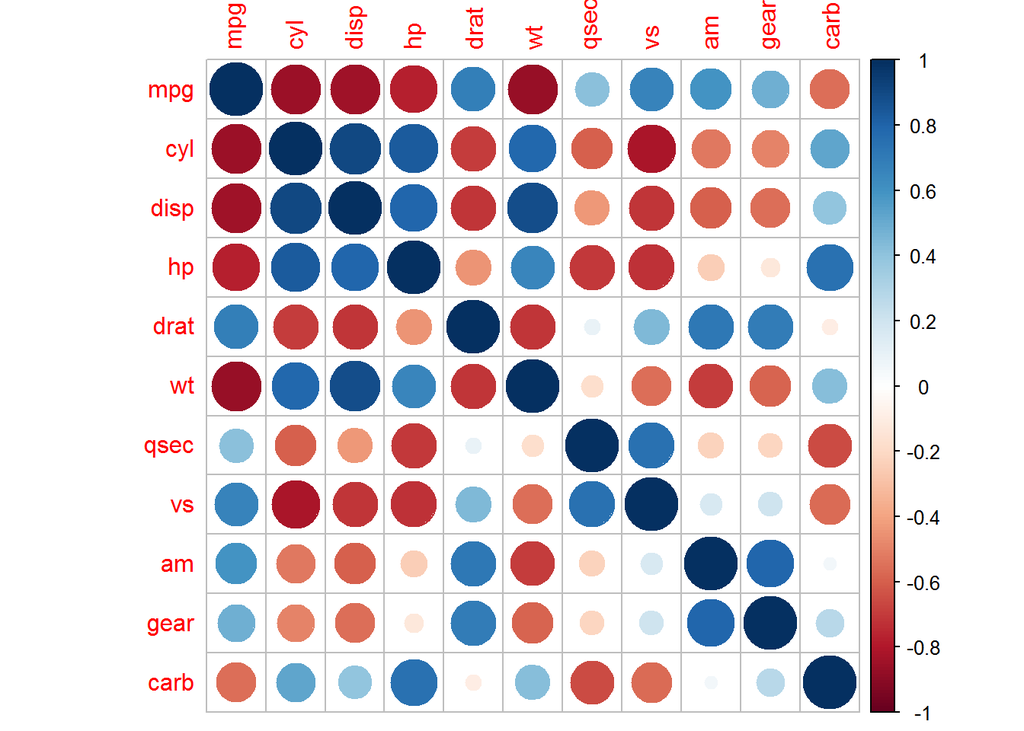

```r
corrplot(cars_cor) # график с аргументами по умолчанию
```

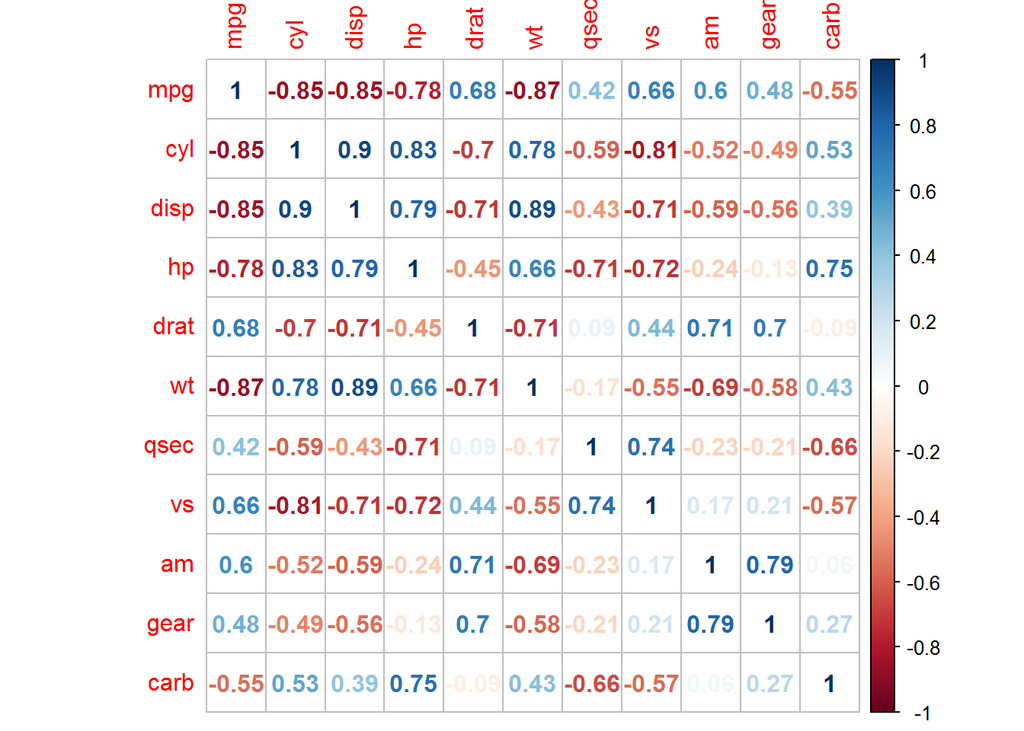

```r
corrplot(cars_cor, method = 'number') # график со значениями корреляции
```

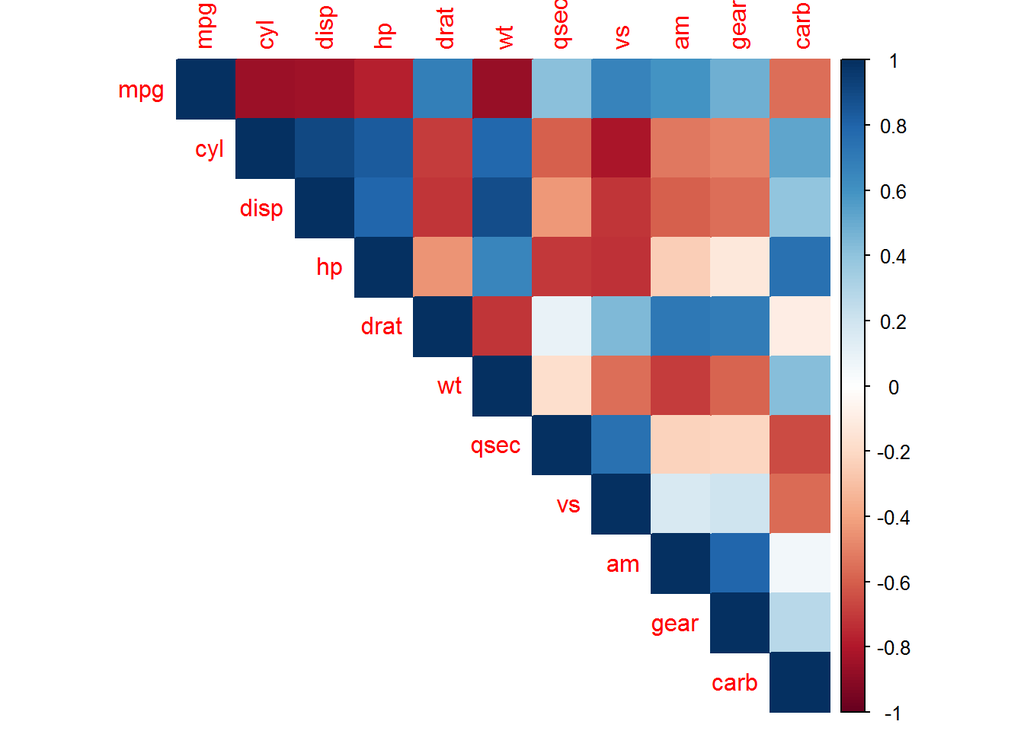

```r
corrplot(cars_cor, method = 'color', type = 'upper') # только правая верхняя часть
```

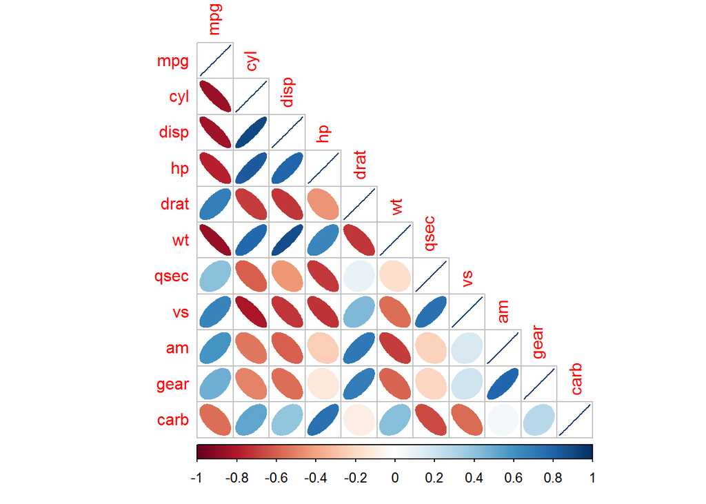

```r
corrplot(cars_cor, method = 'ellipse', type = 'lower') # только левая нижняя часть
```

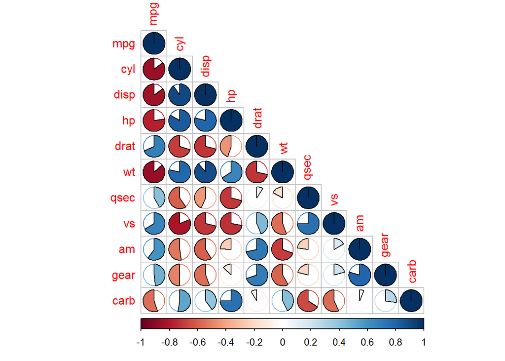

```r
corrplot(cars_cor, method = 'pie', type = 'lower') # только левая нижняя часть
```

[figure not shown]

```r
corrplot(cars_cor, method = 'shade', type = 'lower') # только левая нижняя часть
```

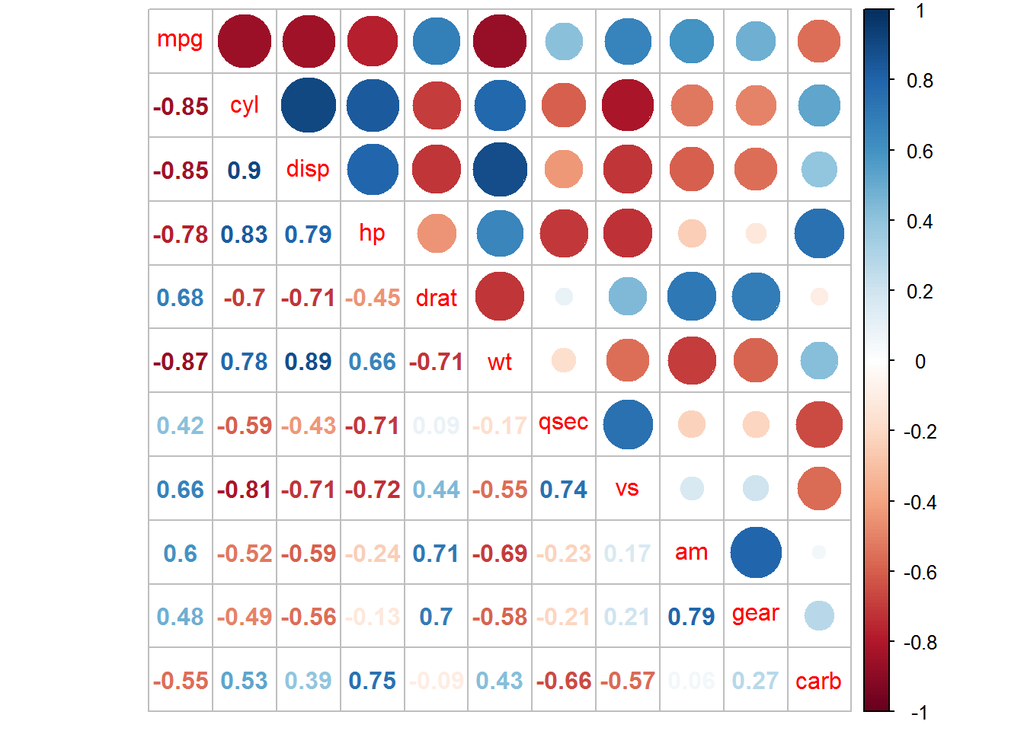

```r
corrplot.mixed(cars_cor) # можно миксовать!
```

Красивые примеры из [виньетки пакета](https://cran.r-project.org/web/packages/corrplot/vignettes/corrplot-intro.html). И менее красочная, но подробнейшая справка - `?corrplot`.

- Упражнение 6.

Возьмём таблицу `airquality`, ежедневные измерения качества воздуха в Нью-Йорке в 1973 году. Подробности в справке :) - Сколько наблюдений и переменных в наборе данных `airquality`? Есть ли пропуски в данных? - Посчитайте корреляции, игнорируя пропущенные значения - Визуализируйте корреляции: значения должны быть только ниже диагонали, внутри графика должны стоять эллипсы. Вся необходимая информация есть в справке!

```r
skim(airquality)
```

```
## Skim summary statistics
##  n obs: 153
##  n variables: 6
##
## Variable type: integer
##  variable missing complete   n   mean    sd p0    p25   p50    p75 p100
##       Day       0      153 153  15.8   8.86  1   8     16    23      31
##     Month       0      153 153   6.99  1.42  5   6      7     8       9
##     Ozone      37      116 153  42.13 32.99  1  18     31.5  63.25  168
##   Solar.R       7      146 153 185.93 90.06  7 115.75 205   258.75  334
##      Temp       0      153 153  77.88  9.47 56  72     79    85      97
##      hist
##  ▇▇▇▇▆▇▇▇
##  ▇▇▁▇▁▇▁▇
##  ▇▆▃▃▂▁▁▁
##  ▃▃▃▃▅▇▇▃
##  ▂▂▃▆▇▇▃▃
##
## Variable type: numeric
##  variable missing complete   n  mean   sd  p0 p25 p50  p75 p100     hist
##      Wind       0      153 153  9.96 3.52 1.7 7.4 9.7 11.5 20.7 ▁▃▇▇▅▅▁▁
```

```r
cmatrix <- cor(airquality, use = 'pairwise.complete.obs') # игнорируем пропущенные значения
cmatrix
```

```
##               Ozone     Solar.R        Wind       Temp        Month
## Ozone    1.00000000  0.34834169 -0.60154653  0.6983603  0.164519314
## Solar.R  0.34834169  1.00000000 -0.05679167  0.2758403 -0.075300764
## Wind    -0.60154653 -0.05679167  1.00000000 -0.4579879 -0.178292579
## Temp     0.69836034  0.27584027 -0.45798788  1.0000000  0.420947252
## Month    0.16451931 -0.07530076 -0.17829258  0.4209473  1.000000000
## Day     -0.01322565 -0.15027498  0.02718090 -0.1305932 -0.007961763
##                  Day
## Ozone   -0.013225647
## Solar.R -0.150274979
## Wind     0.027180903
## Temp    -0.130593175
## Month   -0.007961763
## Day      1.000000000
```

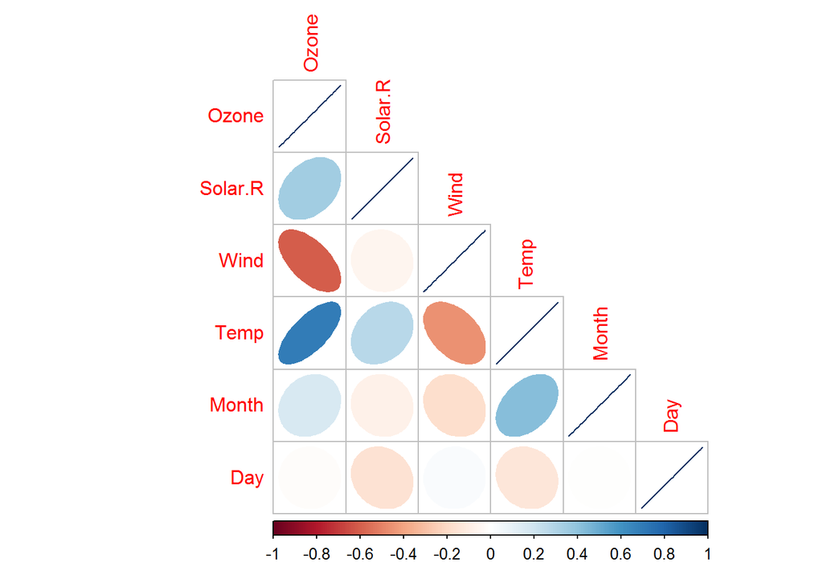

```r
corrplot(cmatrix, method = 'ellipse', type = 'lower')
```

# 5 Группировка данных

Иногда мы хотим сгруппировать наблюдения по нескольким переменным и для каждой группы что-то посчитать!

Посчитаем для каждого цвета бриллианта максимальную, минимальную цену!

```r
report <- group_by(diamonds, color) %>%
  summarise(min_price = min(price), max_price = max(price))
report
```

```
## # A tibble: 7 x 3
##   color min_price max_price
##   <ord>     <dbl>     <dbl>
## 1 D           357     18693
## 2 E           326     18731
## 3 F           342     18791
## 4 G           354     18818
## 5 H           337     18803
## 6 I           334     18823
## 7 J           335     18710
```

```r
report2 <- group_by(diamonds, `cut`) %>%
summarise(med_price = median(price), sd_price = sd(price), n_obs = n()) %>%
top_n(3, med_price)
report2
```

```
## # A tibble: 3 x 4
##   cut     med_price sd_price n_obs
##   <ord>       <dbl>    <dbl> <int>
## 1 Fair        3282     3560.  1610
## 2 Good        3050.    3682.  4906
## 3 Premium     3185     4349. 13791
```

```r
report3 <- group_by(diamonds, clarity) %>%
summarise(mean_price = mean(price), med_carat = median(carat), n_obs = n()) %>%
arrange(med_carat)
report3
```

```
## # A tibble: 8 x 4
##   clarity mean_price med_carat n_obs
##   <ord>        <dbl>     <dbl> <int>
## 1 IF           2865.     0.35   1790
## 2 VVS1         2523.     0.39   3655
## 3 VVS2         3284.     0.44   5066
## 4 VS1          3839.     0.570  8171
## 5 VS2          3925.     0.63  12258
## 6 SI1          3996.     0.76  13065
## 7 SI2          5063.     1.01   9194
## 8 I1           3924.     1.12    741
```

# 6 Грамматика графиков

Графиков в R много и разных. Мы сосредоточимся на грамматике графиков и пакете `ggplot2`.

Каждый график состоит из нескольких слоёв (layer). Даже самый простой график мы разложим на слои: точки и подписи осей.

У типичного слоя мы указываем: - откуда брать данные; - геометрию (geometry): точки на плоскости, скрипки, линия, столбцы гистограммы, куски карты, линии уровня и т.д. - как каждая переменная из набора данных превращается в эстетику.

Для простого графика это занудство, но для сложного это настоящее спасение! Попробуем быть занудами :)

Обычная диаграмма рассеяния!

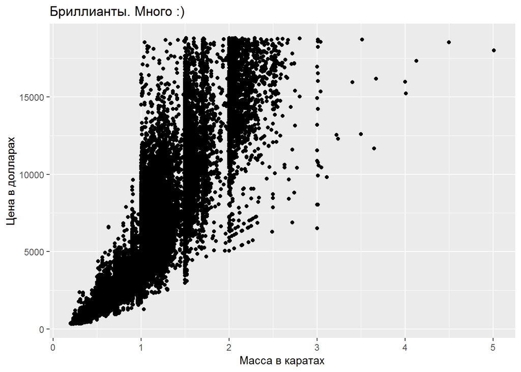

```r
ggplot(data = diamonds) +
  geom_point(aes(x = carat, y = price)) +
  labs(x = 'Масса в каратах', y = 'Цена в долларах', title = 'Бриллианты. Много :)')
```

Задействуем эстетику цвета!

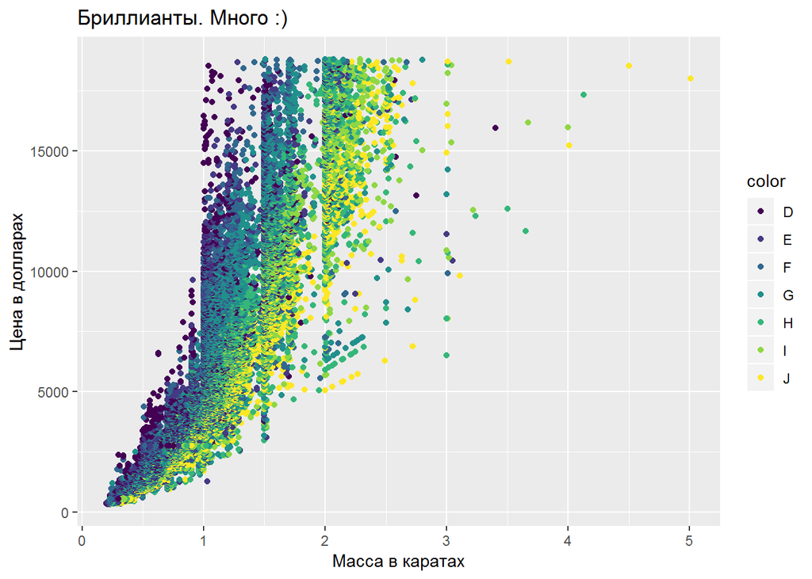

```r
ggplot(data = diamonds) +
  geom_point(aes(x = carat, y = price, color = color)) +
  labs(x = 'Масса в каратах', y = 'Цена в долларах', title = 'Бриллианты. Много :)')
```

Добавим новый слой вертикальных линий! Задействуем эстетику цвета!

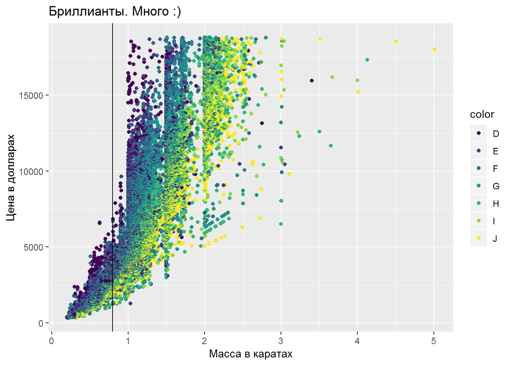

```r
ggplot(data = diamonds) +
  geom_point(aes(x = carat, y = price, color = color)) +
  geom_vline(aes(xintercept = mean(carat))) +
  labs(x = 'Масса в каратах', y = 'Цена в долларах', title = 'Бриллианты. Много :)')
```

- Упражнение 9.

Снова возьмём встроенные данные про машины `mtcars`.

Постройте диаграмму рассеяния сопоставив эстетики графика и переменные так: - координата `x` - пробег в милях на один галлон бензина `mpg` - координата `y` - объём двигателя `disp` - форма `shape` - наличие ручной коробки передач, переменная `am`

```r
skim(mtcars)
```

```
## Skim summary statistics
##  n obs: 32
##  n variables: 11
##
## Variable type: numeric
##  variable missing complete  n   mean     sd    p0    p25    p50    p75
##        am       0       32 32   0.41   0.5   0      0      0      1
##      carb       0       32 32   2.81   1.62  1      2      2      4
##       cyl       0       32 32   6.19   1.79  4      4      6      8
##      disp       0       32 32 230.72 123.94 71.1  120.83 196.3  326
##      drat       0       32 32   3.6    0.53  2.76   3.08   3.7    3.92
##      gear       0       32 32   3.69   0.74  3      3      4      4
##        hp       0       32 32 146.69  68.56 52     96.5  123    180
##       mpg       0       32 32  20.09   6.03 10.4   15.43  19.2   22.8
##      qsec       0       32 32  17.85   1.79 14.5   16.89  17.71  18.9
##        vs       0       32 32   0.44   0.5   0      0      0      1
##        wt       0       32 32   3.22   0.98  1.51   2.58   3.33   3.61
##    p100     hist
##    1    ▇▁▁▁▁▁▁▆
##    8    ▆▇▂▇▁▁▁▁
##    8    ▆▁▁▃▁▁▁▇
##  472    ▇▆▁▂▅▃▁▂
##    4.93 ▃▇▁▅▇▂▁▁
##    5    ▇▁▁▆▁▁▁▂
##  335    ▃▇▃▅▂▃▁▁
##   33.9  ▃▇▇▇▃▂▂▂
##   22.9  ▃▂▇▆▃▃▁▁
##    1    ▇▁▁▁▁▁▁▆
##    5.42 ▃▃▃▇▆▁▁▂
```

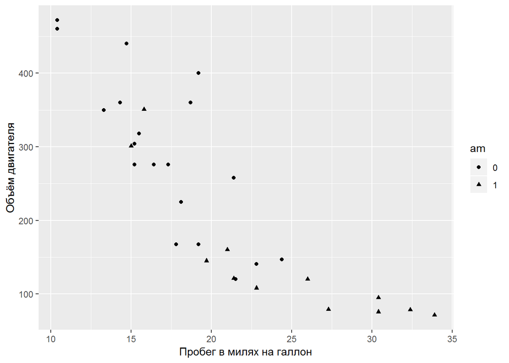

```r
mtcars<-mutate(mtcars,am = factor(am))
ggplot(data = mtcars) +
geom_point(aes(x = mpg, y = disp, shape = am)) +
labs(x = 'Пробег в милях на галлон', y = 'Объём двигателя')
```

Добавьте к графику горизонтальную линию на уровне медианного объема двигателя

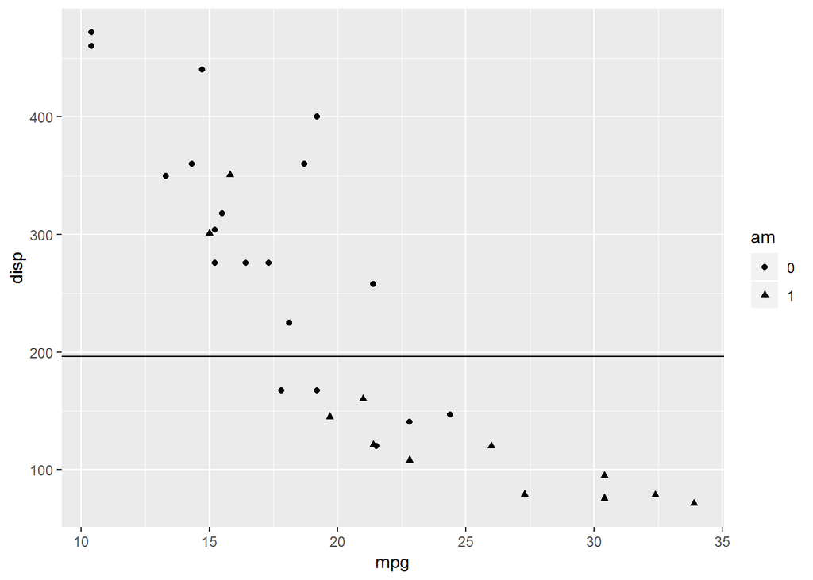

```r
ggplot(data = mtcars) +
geom_point(aes(x = mpg, y = disp, shape = am)) +
geom_hline(aes(yintercept = median(disp)))
```

```r
labs(x = 'Пробег в милях на галлон', y = 'Объём двигателя')
```

```
## $x
## [1] "Пробег в милях на галлон"
##
## $y
## [1] "Объём двигателя"
##
## attr(,"class")
## [1] "labels"
```

Нарисуйте гистограмму пробега на одну милю `mpg`:

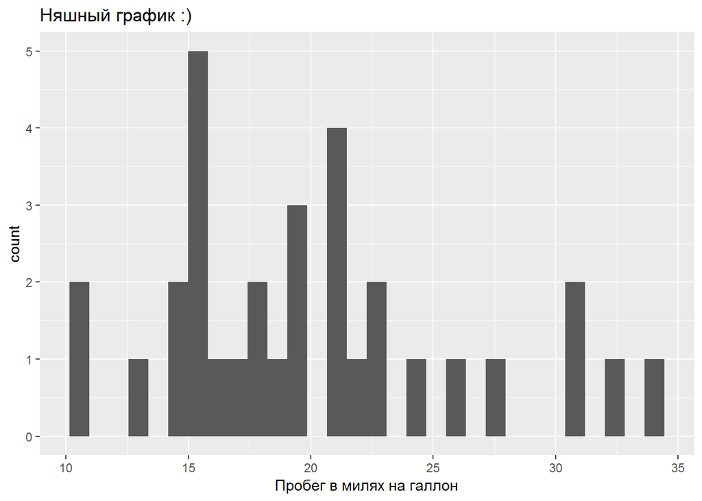

```r
ggplot(data = mtcars) +
geom_histogram(aes(x = mpg)) +
labs(x = 'Пробег в милях на галлон', title = 'Няшный график :)')
```

Очень подробная документация по [ggplot](http://ggplot2.tidyverse.org).

Глава про графики в [R for data science](http://r4ds.had.co.nz/graphics-for-communication.html).

# 7 Графики для качественных переменных

Количество цилиндров `cyl` принимает слишком мало значений, поэтому определим `cyl` как факторную переменную. Это действие влияет на то, как строятся графики!

```r
mtcars2 <- mutate(mtcars, cyl = factor(cyl))
skim(mtcars2)
```

```
## Skim summary statistics
##  n obs: 32
##  n variables: 11
##
## Variable type: factor
##  variable missing complete  n n_unique                top_counts ordered
##        am       0       32 32        2       0: 19, 1: 13, NA: 0   FALSE
##       cyl       0       32 32        3 8: 14, 4: 11, 6: 7, NA: 0   FALSE
##
## Variable type: numeric
##  variable missing complete  n   mean     sd    p0    p25    p50    p75
##      carb       0       32 32   2.81   1.62  1      2      2      4
##      disp       0       32 32 230.72 123.94 71.1  120.83 196.3  326
##      drat       0       32 32   3.6    0.53  2.76   3.08   3.7    3.92
##      gear       0       32 32   3.69   0.74  3      3      4      4
##        hp       0       32 32 146.69  68.56 52     96.5  123    180
##       mpg       0       32 32  20.09   6.03 10.4   15.43  19.2   22.8
##      qsec       0       32 32  17.85   1.79 14.5   16.89  17.71  18.9
##        vs       0       32 32   0.44   0.5   0      0      0      1
##        wt       0       32 32   3.22   0.98  1.51   2.58   3.33   3.61
##    p100     hist
##    8    ▆▇▂▇▁▁▁▁
##  472    ▇▆▁▂▅▃▁▂
##    4.93 ▃▇▁▅▇▂▁▁
##    5    ▇▁▁▆▁▁▁▂
##  335    ▃▇▃▅▂▃▁▁
##   33.9  ▃▇▇▇▃▂▂▂
##   22.9  ▃▂▇▆▃▃▁▁
##    1    ▇▁▁▁▁▁▁▆
##    5.42 ▃▃▃▇▆▁▁▂
```

Посмотрим на распределение расхода бензина на милю (`mpg`) в зависимости от количества цилиндров.

Вместо устаревшего графика “ларь-да-усы” будем строить скрипичный график (violin plot) командой `geom_viloin()` из пакета `ggplot2`.

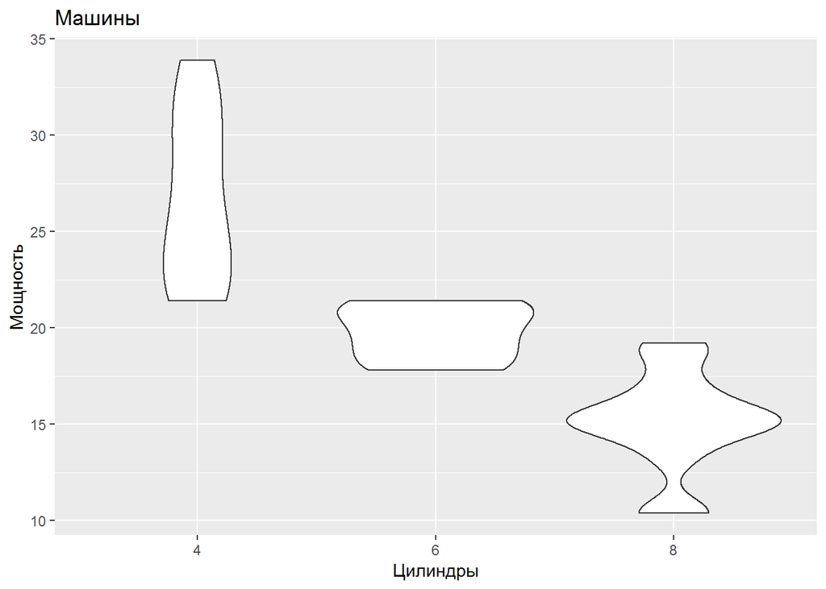

```r
ggplot(data = mtcars2) +
  geom_violin(aes(x = cyl, y = mpg)) +
  labs(x = 'Цилиндры', y = 'Мощность', title = 'Машины')
```

С помощью функции `facet_grid()` можно разбить график на две панели: для ручной и автоматической коробки передач, `am`.

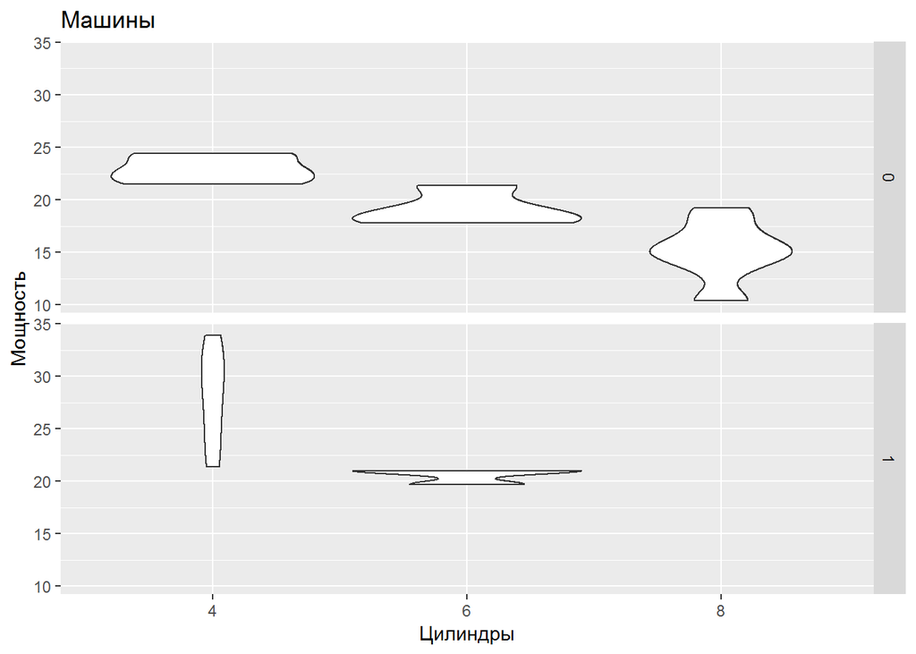

```r
ggplot(data = mtcars2) +
  geom_violin(aes(x = cyl, y = mpg)) +
  facet_grid(am ~ .) +
  labs(x = 'Цилиндры', y = 'Мощность', title = 'Машины')
```

- Упражнение 10.

Добавить новый шмат кода можно через меню `Code` - `Insert chunk`.

- Что изменится в панелях графика, если внутри `facet_grid` написать `. ~ am`?
- Как с клавиатуры без мышки вставить шмат кода?

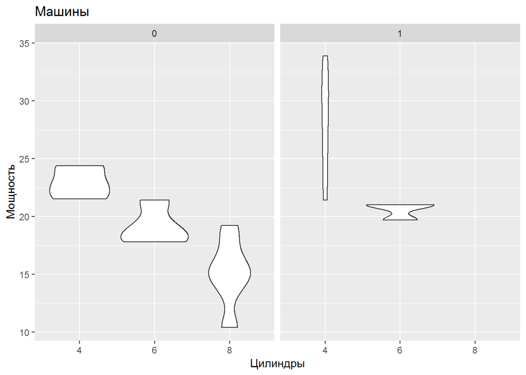

```r
ggplot(data = mtcars2) +
  geom_violin(aes(x = cyl, y = mpg)) +
  facet_grid(.~ am) +
  labs(x = 'Цилиндры', y = 'Мощность', title = 'Машины')
```

## 7.1 Потоковый график

И для примера более сложный график с кучей слоёв!

Вспомним старую таблицу частот:

```r
freq_table
```

```
## # A tibble: 20 x 4
## # Groups:   wage, race [?]
##    wage  race   sector        freq
##    <fct> <fct>  <fct>        <int>
##  1 <=50K Female ?              787
##  2 <=50K Female Gov           1361
##  3 <=50K Female Never-worked     2
##  4 <=50K Female Private       7026
##  5 <=50K Female Self_emp       411
##  6 <=50K Female Without-pay      5
##  7 <=50K Male   ?              858
##  8 <=50K Male   Gov           1649
##  9 <=50K Male   Never-worked     5
## 10 <=50K Male   Private      10707
## 11 <=50K Male   Self_emp      1900
## 12 <=50K Male   Without-pay      9
## 13 >50K  Female ?               52
## 14 >50K  Female Gov            278
## 15 >50K  Female Private        726
## 16 >50K  Female Self_emp       123
## 17 >50K  Male   ?              139
## 18 >50K  Male   Gov           1063
## 19 >50K  Male   Private       4237
## 20 >50K  Male   Self_emp      1223
```

Нарисуем две вариации потокового графика с помощью пакета `ggalluvial`

```
## Missing alluvia for some stratum combinations.
## Missing alluvia for some stratum combinations.
## Missing alluvia for some stratum combinations.
```

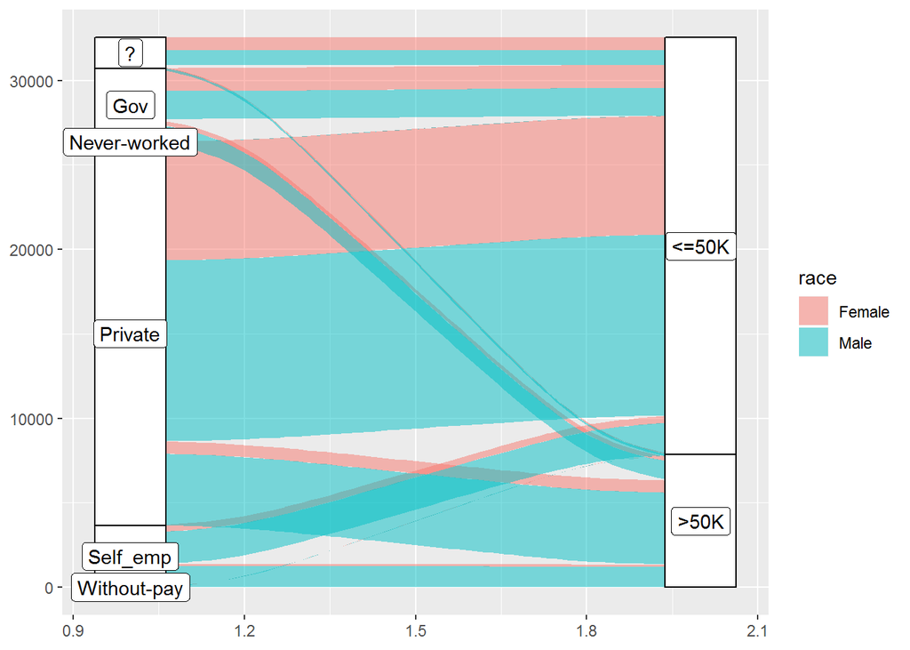

```r
ggplot(data = freq_table,
       aes(weight = freq, axis1 = sector, axis2 = wage)) +
  geom_alluvium(aes(fill = race), width = 1/12) +
      geom_stratum(width = 1/8) + geom_label(stat = "stratum", label.strata = TRUE)
```

```
## Missing alluvia for some stratum combinations.
## Missing alluvia for some stratum combinations.
## Missing alluvia for some stratum combinations.
```

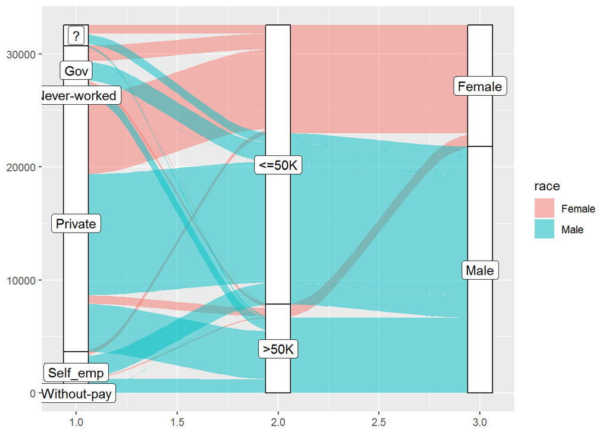

```r
ggplot(data = freq_table,
         aes(weight = freq, axis1 = sector, axis2 = wage, axis3 = race)) +
    geom_alluvium(aes(fill = race), width = 1/12) +
    geom_stratum(width = 1/8) +
    geom_label(stat = "stratum", label.strata = TRUE)
```

- Упражнение 11.
- Какой элемент графика рисует геометрия `geom_stratum`, а какой - геометрия `geom_alluvium`?

Подсказка: просто удалите по очереди каждую из этих строк, и посмотрите, что исчезает!

Вдохновиться примерами и нарисовать себе “такой же, но с перламутровыми пуговицами” [потоковый график](https://cran.r-project.org/web/packages/ggalluvial/vignettes/ggalluvial.html)

# 8 Соединение таблиц

Таблицы можно создавать и самим c помощью функции `tibble()`.

```r
mx <- tibble(ID = c('A', 'B', 'C', 'D', 'E'),
           x = c(1, 2, 4, 1, 8))
mx
```

```
## # A tibble: 5 x 2
##   ID        x
##   <chr> <dbl>
## 1 A         1
## 2 B         2
## 3 C         4
## 4 D         1
## 5 E         8
```

- Упражнение 12.

Создайте таблицу `my`, с двумя столбцами: `ID` и `y`, и пятью значениями в каждом. Столбец `y` можно заполнить числами произвольно.

```r
my <- tibble(ID = c('A', 'C', 'D', 'F', 'E'),
           y = c(13,12,14,1,5))
my
```

```
## # A tibble: 5 x 2
##   ID        y
##   <chr> <dbl>
## 1 A        13
## 2 C        12
## 3 D        14
## 4 F         1
## 5 E         5
```

Таблицы можно соединять! Существует четыре способа сделать это: - `left_join(x, y, by = 'colname')` сохраняет все наблюдения в таблице `x` - `right_join(x, y, by = 'colname')` сохраняет все наблюдения в таблице `y` - `full_join(x, y, by = 'colname')` сохраняет наблюдения из обеих таблиц - `inner_join(x, y, by = 'colname')` объединяет только те строки обеих таблиц, в которых нет пропущенных наблюдений

- Упражнение 13.

Экспериментируем!

```r
left_join(mx, my, by = 'ID')
```

```
## # A tibble: 5 x 3
##   ID        x     y
##   <chr> <dbl> <dbl>
## 1 A         1    13
## 2 B         2    NA
## 3 C         4    12
## 4 D         1    14
## 5 E         8     5
```

```r
right_join(mx, my, by = 'ID')
```

```
## # A tibble: 5 x 3
##   ID        x     y
##   <chr> <dbl> <dbl>
## 1 A         1    13
## 2 C         4    12
## 3 D         1    14
## 4 F        NA     1
## 5 E         8     5
```

```r
inner_join(mx, my, by = 'ID')
```

```
## # A tibble: 4 x 3
##   ID        x     y
##   <chr> <dbl> <dbl>
## 1 A         1    13
## 2 C         4    12
## 3 D         1    14
## 4 E         8     5
```

```r
full_join(mx, my, by = 'ID')
```

```
## # A tibble: 6 x 3
##   ID        x     y
##   <chr> <dbl> <dbl>
## 1 A         1    13
## 2 B         2    NA
## 3 C         4    12
## 4 D         1    14
## 5 E         8     5
## 6 F        NA     1
```

- Сколько наблюдений получается в объединённой таблице в каждом случае?
- Упражнение 14.

Нужно объединить таблицы `flights` и `weather` о вылетах из Нью-Йорка сразу по нескольким столбцам!

- ‘Бросьте взгляд’ на обе таблицы. Какие столбцы совпадают?

```r
glimpse(flights)
```

```
## Observations: 336,776
## Variables: 19
## $ year           <int> 2013, 2013, 2013, 2013, 2013, 2013, 2013, 2013,...
## $ month          <int> 1, 1, 1, 1, 1, 1, 1, 1, 1, 1, 1, 1, 1, 1, 1, 1,...
## $ day            <int> 1, 1, 1, 1, 1, 1, 1, 1, 1, 1, 1, 1, 1, 1, 1, 1,...
## $ dep_time       <int> 517, 533, 542, 544, 554, 554, 555, 557, 557, 55...
## $ sched_dep_time <int> 515, 529, 540, 545, 600, 558, 600, 600, 600, 60...
## $ dep_delay      <dbl> 2, 4, 2, -1, -6, -4, -5, -3, -3, -2, -2, -2, -2...
## $ arr_time       <int> 830, 850, 923, 1004, 812, 740, 913, 709, 838, 7...
## $ sched_arr_time <int> 819, 830, 850, 1022, 837, 728, 854, 723, 846, 7...
## $ arr_delay      <dbl> 11, 20, 33, -18, -25, 12, 19, -14, -8, 8, -2, -...
## $ carrier        <chr> "UA", "UA", "AA", "B6", "DL", "UA", "B6", "EV",...
## $ flight         <int> 1545, 1714, 1141, 725, 461, 1696, 507, 5708, 79...
## $ tailnum        <chr> "N14228", "N24211", "N619AA", "N804JB", "N668DN...
## $ origin         <chr> "EWR", "LGA", "JFK", "JFK", "LGA", "EWR", "EWR"...
## $ dest           <chr> "IAH", "IAH", "MIA", "BQN", "ATL", "ORD", "FLL"...
## $ air_time       <dbl> 227, 227, 160, 183, 116, 150, 158, 53, 140, 138...
## $ distance       <dbl> 1400, 1416, 1089, 1576, 762, 719, 1065, 229, 94...
## $ hour           <dbl> 5, 5, 5, 5, 6, 5, 6, 6, 6, 6, 6, 6, 6, 6, 6, 5,...
## $ minute         <dbl> 15, 29, 40, 45, 0, 58, 0, 0, 0, 0, 0, 0, 0, 0, ...
## $ time_hour      <dttm> 2013-01-01 05:00:00, 2013-01-01 05:00:00, 2013...
```

```r
skim(flights)
```

```
## Skim summary statistics
##  n obs: 336776
##  n variables: 19
##
## Variable type: character
##  variable missing complete      n min max empty n_unique
##   carrier       0   336776 336776   2   2     0       16
##      dest       0   336776 336776   3   3     0      105
##    origin       0   336776 336776   3   3     0        3
##   tailnum    2512   334264 336776   5   6     0     4043
##
## Variable type: integer
##        variable missing complete      n    mean      sd   p0  p25  p50
##        arr_time    8713   328063 336776 1502.05  533.26    1 1104 1535
##             day       0   336776 336776   15.71    8.77    1    8   16
##        dep_time    8255   328521 336776 1349.11  488.28    1  907 1401
##          flight       0   336776 336776 1971.92 1632.47    1  553 1496
##           month       0   336776 336776    6.55    3.41    1    4    7
##  sched_arr_time       0   336776 336776 1536.38  497.46    1 1124 1556
##  sched_dep_time       0   336776 336776 1344.25  467.34  106  906 1359
##            year       0   336776 336776 2013       0    2013 2013 2013
##   p75 p100     hist
##  1940 2400 ▁▁▃▇▆▆▇▆
##    23   31 ▇▇▇▇▆▇▇▇
##  1744 2400 ▁▁▇▆▆▇▆▂
##  3465 8500 ▇▅▂▃▂▁▁▁
##    10   12 ▇▅▇▃▅▇▅▇
##  1945 2359 ▁▁▂▇▆▇▇▆
##  1729 2359 ▁▃▇▆▆▇▇▂
##  2013 2013 ▁▁▁▇▁▁▁▁
##
## Variable type: numeric
##   variable missing complete      n    mean     sd  p0 p25 p50  p75 p100
##   air_time    9430   327346 336776  150.69  93.69  20  82 129  192  695
##  arr_delay    9430   327346 336776    6.9   44.63 -86 -17  -5   14 1272
##  dep_delay    8255   328521 336776   12.64  40.21 -43  -5  -2   11 1301
##   distance       0   336776 336776 1039.91 733.23  17 502 872 1389 4983
##       hour       0   336776 336776   13.18   4.66   1   9  13   17   23
##     minute       0   336776 336776   26.23  19.3    0   8  29   44   59
##      hist
##  ▇▇▂▃▁▁▁▁
##  ▇▁▁▁▁▁▁▁
##  ▇▁▁▁▁▁▁▁
##  ▆▇▂▂▁▁▁▁
##  ▁▃▇▆▅▇▇▂
##  ▇▂▃▃▅▂▃▅
##
## Variable type: POSIXct
##   variable missing complete      n        min        max     median
##  time_hour       0   336776 336776 2013-01-01 2013-12-31 2013-07-03
##  n_unique
##      6936
```

```r
glimpse(weather)
```

```
## Observations: 26,130
## Variables: 15
## $ origin     <chr> "EWR", "EWR", "EWR", "EWR", "EWR", "EWR", "EWR", "E...
## $ year       <dbl> 2013, 2013, 2013, 2013, 2013, 2013, 2013, 2013, 201...
## $ month      <dbl> 1, 1, 1, 1, 1, 1, 1, 1, 1, 1, 1, 1, 1, 1, 1, 1, 1, ...
## $ day        <int> 1, 1, 1, 1, 1, 1, 1, 1, 1, 1, 1, 1, 1, 1, 1, 1, 1, ...
## $ hour       <int> 0, 1, 2, 3, 4, 6, 7, 8, 9, 10, 11, 12, 13, 14, 15, ...
## $ temp       <dbl> 37.04, 37.04, 37.94, 37.94, 37.94, 39.02, 39.02, 39...
## $ dewp       <dbl> 21.92, 21.92, 21.92, 23.00, 24.08, 26.06, 26.96, 28...
## $ humid      <dbl> 53.97, 53.97, 52.09, 54.51, 57.04, 59.37, 61.63, 64...
## $ wind_dir   <dbl> 230, 230, 230, 230, 240, 270, 250, 240, 250, 260, 2...
## $ wind_speed <dbl> 10.35702, 13.80936, 12.65858, 13.80936, 14.96014, 1...
## $ wind_gust  <dbl> 11.918651, 15.891535, 14.567241, 15.891535, 17.2158...
## $ precip     <dbl> 0, 0, 0, 0, 0, 0, 0, 0, 0, 0, 0, 0, 0, 0, 0, 0, 0, ...
## $ pressure   <dbl> 1013.9, 1013.0, 1012.6, 1012.7, 1012.8, 1012.0, 101...
## $ visib      <dbl> 10, 10, 10, 10, 10, 10, 10, 10, 10, 10, 10, 10, 10,...
## $ time_hour  <dttm> 2013-01-01 04:00:00, 2013-01-01 05:00:00, 2013-01-...
```

```r
skim(weather)
```

```
## Skim summary statistics
##  n obs: 26130
##  n variables: 15
##
## Variable type: character
##  variable missing complete     n min max empty n_unique
##    origin       0    26130 26130   3   3     0        3
##
## Variable type: integer
##  variable missing complete     n  mean   sd p0 p25 p50 p75 p100     hist
##       day       0    26130 26130 15.68 8.77  1   8  16  23   31 ▇▇▇▇▆▇▇▆
##      hour       0    26130 26130 11.52 6.92  0   6  12  18   23 ▇▇▇▇▇▇▇▇
##
## Variable type: numeric
##    variable missing complete     n      mean     sd      p0     p25
##        dewp       1    26129 26130   41.39    19.37   -9.94   26.06
##       humid       1    26129 26130   62.35    19.2    12.74   46.99
##       month       0    26130 26130    6.51     3.44    1       4
##      precip       0    26130 26130    0.0027   0.02    0       0
##    pressure    2730    23400 26130 1017.9      7.42  983.8  1012.9
##        temp       1    26129 26130   55.2     17.78   10.94   39.92
##       visib       0    26130 26130    9.2      2.14    0      10
##    wind_dir     418    25712 26130  198.07   107.84    0     120
##   wind_gust       3    26127 26130   11.96     9.81    0       7.95
##  wind_speed       3    26127 26130   10.4      8.52    0       6.9
##        year       0    26130 26130 2013        0    2013    2013
##      p50     p75    p100     hist
##    42.08   57.92   78.08 ▁▃▆▇▆▇▇▅
##    61.66   78.62  100    ▁▂▆▇▇▆▇▃
##     7       9      12    ▇▅▇▃▅▇▅▇
##     0       0       1.18 ▇▁▁▁▁▁▁▁
##  1017.6  1023    1042.1  ▁▁▁▅▇▆▂▁
##    55.04   69.98  100.04 ▁▅▇▇▇▇▃▁
##    10      10      10    ▁▁▁▁▁▁▁▇
##   220     290     360    ▆▃▂▆▆▇▇▆
##    10.59   15.89 1206.43 ▇▁▁▁▁▁▁▁
##     9.21   13.81 1048.36 ▇▁▁▁▁▁▁▁
##  2013    2013    2013    ▁▁▁▇▁▁▁▁
##
## Variable type: POSIXct
##   variable missing complete     n        min        max     median
##  time_hour       0    26130 26130 2013-01-01 2013-12-31 2013-07-01
##  n_unique
##      8718
```

- Присоедините к таблице `flights` таблицу `weather` с помощью функции `left_join()`. В качестве аргумента `by` используйте вектор из названий общих столбцов: `year`, `month`, `day`, `hour` и `origin`.
- Сколько наблюдений в объединённой таблице?

```r
left <- left_join(flights, weather, by = c('year', 'month', 'day', 'hour', 'origin'))
  glimpse(left)
```

```
## Observations: 336,776
## Variables: 29
## $ year           <dbl> 2013, 2013, 2013, 2013, 2013, 2013, 2013, 2013,...
## $ month          <dbl> 1, 1, 1, 1, 1, 1, 1, 1, 1, 1, 1, 1, 1, 1, 1, 1,...
## $ day            <int> 1, 1, 1, 1, 1, 1, 1, 1, 1, 1, 1, 1, 1, 1, 1, 1,...
## $ dep_time       <int> 517, 533, 542, 544, 554, 554, 555, 557, 557, 55...
## $ sched_dep_time <int> 515, 529, 540, 545, 600, 558, 600, 600, 600, 60...
## $ dep_delay      <dbl> 2, 4, 2, -1, -6, -4, -5, -3, -3, -2, -2, -2, -2...
## $ arr_time       <int> 830, 850, 923, 1004, 812, 740, 913, 709, 838, 7...
## $ sched_arr_time <int> 819, 830, 850, 1022, 837, 728, 854, 723, 846, 7...
## $ arr_delay      <dbl> 11, 20, 33, -18, -25, 12, 19, -14, -8, 8, -2, -...
## $ carrier        <chr> "UA", "UA", "AA", "B6", "DL", "UA", "B6", "EV",...
## $ flight         <int> 1545, 1714, 1141, 725, 461, 1696, 507, 5708, 79...
## $ tailnum        <chr> "N14228", "N24211", "N619AA", "N804JB", "N668DN...
## $ origin         <chr> "EWR", "LGA", "JFK", "JFK", "LGA", "EWR", "EWR"...
```

[output cut: 16 more lines]

- Повторите соединение двух таблиц, но используя `inner_join()`. Сколько наблюдений в получившейся таблице?
- В чём разница `left_join` и `inner_join`?

```r
inner <- inner_join(flights, weather, by = c('year', 'month', 'day', 'hour', 'origin'))
glimpse(inner)
```

```
## Observations: 335,563
## Variables: 29
## $ year           <dbl> 2013, 2013, 2013, 2013, 2013, 2013, 2013, 2013,...
## $ month          <dbl> 1, 1, 1, 1, 1, 1, 1, 1, 1, 1, 1, 1, 1, 1, 1, 1,...
## $ day            <int> 1, 1, 1, 1, 1, 1, 1, 1, 1, 1, 1, 1, 1, 1, 1, 1,...
## $ dep_time       <int> 554, 555, 557, 557, 558, 558, 558, 558, 558, 55...
## $ sched_dep_time <int> 600, 600, 600, 600, 600, 600, 600, 600, 600, 60...
## $ dep_delay      <dbl> -6, -5, -3, -3, -2, -2, -2, -2, -2, -1, -1, 0, ...
## $ arr_time       <int> 812, 913, 709, 838, 753, 849, 853, 924, 923, 94...
## $ sched_arr_time <int> 837, 854, 723, 846, 745, 851, 856, 917, 937, 91...
## $ arr_delay      <dbl> -25, 19, -14, -8, 8, -2, -3, 7, -14, 31, -8, -7...
## $ carrier        <chr> "DL", "B6", "EV", "B6", "AA", "B6", "B6", "UA",...
## $ flight         <int> 461, 507, 5708, 79, 301, 49, 71, 194, 1124, 707...
## $ tailnum        <chr> "N668DN", "N516JB", "N829AS", "N593JB", "N3ALAA...
## $ origin         <chr> "LGA", "EWR", "LGA", "JFK", "LGA", "JFK", "JFK"...
```

[output cut: 16 more lines]

# 9 Длинные и широкие таблицы

Таблицы бывают длинными и широкими! При поступлении нового наблюдения длинная растёт в длину, а широкая может и в ширину :)

Возьмём квартальные данные [Росстата](http://www.gks.ru/free_doc/new_site/vvp/kv/tab35.htm) о ВВП по источникам доходов.

```r
gdp <- import('gdp.xls')
glimpse(gdp)
```

```
## Observations: 4
## Variables: 29
## $ X__1             <chr> "Валовой внутренний продукт", "оплата труда н...
## $ `1 квартал 2011` <dbl> 13028.844, 6055.775, 1807.421, 5165.648
## $ `2 квартал 2011` <dbl> 14481.142, 6469.798, 2205.521, 5805.824
## $ `3 квартал 2011` <dbl> 15805.582, 6678.376, 2280.732, 6846.474
## $ `4 квартал 2011` <dbl> 16966.973, 7182.727, 2453.331, 7330.951
## $ `1 квартал 2012` <dbl> 15182.987, 6991.065, 2194.436, 5997.486
## $ `2 квартал 2012` <dbl> 16472.215, 7448.678, 2582.311, 6441.226
## $ `3 квартал 2012` <dbl> 17733.545, 7615.371, 2423.306, 7694.848
## $ `4 квартал 2012` <dbl> 18775.136, 8146.048, 2630.635, 7998.463
## $ `1 квартал 2013` <dbl> 16375.261, 7828.690, 2335.080, 6211.491
## $ `2 квартал 2013` <dbl> 17538.839, 8350.152, 2572.417, 6616.269
## $ `3 квартал 2013` <dbl> 19058.114, 8569.038, 2522.510, 7966.566
## $ `4 квартал 2013` <dbl> 20161.681, 9044.402, 2632.313, 8484.967
```

[output cut: 16 more lines]

```r
gdp
```

```
##                                                                                                                         X__1
## 1                                                                                                 Валовой внутренний продукт
## 2 оплата труда наемных работников (включая оплату труда и смешанные доходы, не наблюдаемые прямыми статистическими методами)
## 3                                                                                     чистые налоги на производство и импорт
## 4                                                                       валовая прибыль экономики и валовые смешанные доходы
##   1 квартал 2011 2 квартал 2011 3 квартал 2011 4 квартал 2011
## 1      13028.844      14481.142      15805.582      16966.973
## 2       6055.775       6469.798       6678.376       7182.727
## 3       1807.421       2205.521       2280.732       2453.331
## 4       5165.648       5805.824       6846.474       7330.951
##   1 квартал 2012 2 квартал 2012 3 квартал 2012 4 квартал 2012
## 1      15182.987      16472.215      17733.545      18775.136
## 2       6991.065       7448.678       7615.371       8146.048
## 3       2194.436       2582.311       2423.306       2630.635
## 4       5997.486       6441.226       7694.848       7998.463
```

[output cut: 25 more lines]

Обнаружив неудачное название переменной переименуем её сразу!

```r
gdp <- rename(gdp, indicator = X__1)
```

Чтобы превратить широкую таблицу в длинную, нужна функция `melt()` из пакета `reshape2`.

Столбцы растают и стекут в новую переменную `year`. Если столбец нужно сохранить, то его надо перечислить в списке `id`.

```r
long_gdp <- melt(gdp, id = 'indicator', variable.name = 'year')
head(long_gdp, 30) # первые 30 наблюдений
```

```
##                                                                                                                     indicator
## 1                                                                                                  Валовой внутренний продукт
## 2  оплата труда наемных работников (включая оплату труда и смешанные доходы, не наблюдаемые прямыми статистическими методами)
## 3                                                                                      чистые налоги на производство и импорт
## 4                                                                        валовая прибыль экономики и валовые смешанные доходы
## 5                                                                                                  Валовой внутренний продукт
## 6  оплата труда наемных работников (включая оплату труда и смешанные доходы, не наблюдаемые прямыми статистическими методами)
## 7                                                                                      чистые налоги на производство и импорт
## 8                                                                        валовая прибыль экономики и валовые смешанные доходы
## 9                                                                                                  Валовой внутренний продукт
## 10 оплата труда наемных работников (включая оплату труда и смешанные доходы, не наблюдаемые прямыми статистическими методами)
## 11                                                                                     чистые налоги на производство и импорт
## 12                                                                       валовая прибыль экономики и валовые смешанные доходы
## 13                                                                                                 Валовой внутренний продукт
## 14 оплата труда наемных работников (включая оплату труда и смешанные доходы, не наблюдаемые прямыми статистическими методами)
```

[output cut: 47 more lines]

Чтобы сделать обратное — перевести длинную таблицу в широкую — понадобится функция `dcast()`.

Здесь тупому компьютеру умный Homo Sapiens укажет: - какая переменная пойдёт по строкам новой таблицы: `cut` - какая переменная пойдёт по столбцам новой таблицы: `color` - какая переменная пойдёт внутрь таблицы: `price` - как реагировать компьютеру, если окажется в данных несколько кандидатов в одну ячейку таблицы: взять `mean`

```r
dcast(diamonds, cut ~ color, value.var = "price", fun.aggregate = mean)
```

```
##         cut        D        E        F        G        H        I        J
## 1      Fair 4291.061 3682.312 3827.003 4239.255 5135.683 4685.446 4975.655
## 2      Good 3405.382 3423.644 3495.750 4123.482 4276.255 5078.533 4574.173
## 3 Very Good 3470.467 3214.652 3778.820 3872.754 4535.390 5255.880 5103.513
## 4   Premium 3631.293 3538.914 4324.890 4500.742 5216.707 5946.181 6294.592
## 5     Ideal 2629.095 2597.550 3374.939 3720.706 3889.335 4451.970 4918.186
```

- Упражнение 15.

Из данных про воздух в Нью-Йорке `airquality` сделайте длинную таблицу. В качестве идентификаторов возьмите переменные `Month` и `Day`.

```r
air_long <- melt(airquality, id = c('Month', 'Day')) # id оставлеет указанные столбцы
air_long
```

```
##     Month Day variable value
## 1       5   1    Ozone  41.0
## 2       5   2    Ozone  36.0
## 3       5   3    Ozone  12.0
## 4       5   4    Ozone  18.0
## 5       5   5    Ozone    NA
## 6       5   6    Ozone  28.0
## 7       5   7    Ozone  23.0
## 8       5   8    Ozone  19.0
## 9       5   9    Ozone   8.0
## 10      5  10    Ozone    NA
## 11      5  11    Ozone   7.0
## 12      5  12    Ozone  16.0
## 13      5  13    Ozone  11.0
## 14      5  14    Ozone  14.0
```

[output cut: 598 more lines]

А из получившейся длинной таблицы восстановите исходную!

```r
air_wide <- dcast(air_long, Day + Month ~ variable) # вместо пропуска должна быть переменная с несколькими значениями
air_wide
```

```
##     Day Month Ozone Solar.R Wind Temp
## 1     1     5    41     190  7.4   67
## 2     1     6    NA     286  8.6   78
## 3     1     7   135     269  4.1   84
## 4     1     8    39      83  6.9   81
## 5     1     9    96     167  6.9   91
## 6     2     5    36     118  8.0   72
## 7     2     6    NA     287  9.7   74
## 8     2     7    49     248  9.2   85
## 9     2     8     9      24 13.8   81
## 10    2     9    78     197  5.1   92
## 11    3     5    12     149 12.6   74
## 12    3     6    NA     242 16.1   67
## 13    3     7    32     236  9.2   81
## 14    3     8    16      77  7.4   82
```

[output cut: 139 more lines]

Ура :)